# Proyecto Final~ Datos espaciales y espaciotemporales

David Miralles Argente

23/mayo/2023

```r
knitr::opts_chunk$set(echo = TRUE, warning=FALSE, cache=FALSE, message=FALSE)
```

## **Introducción y carga de datos**

### LIBRERIAS

```r
#Librerias

library(DBI)
library(odbc)
library(rnaturalearth)
library(osmdata)
library(tidyverse)
library(sf)
library(ggmap)
library(spatstat)
library(lattice)
library(splancs)
library(mapSpain)
library(units)
library(spatstat.geom)
```

### MAPA DE LA PENINSULA IBERICA

Creamos el mapa de la Peninsula Ibérica sobre el que pintaremos nuestros datos (vehículos)

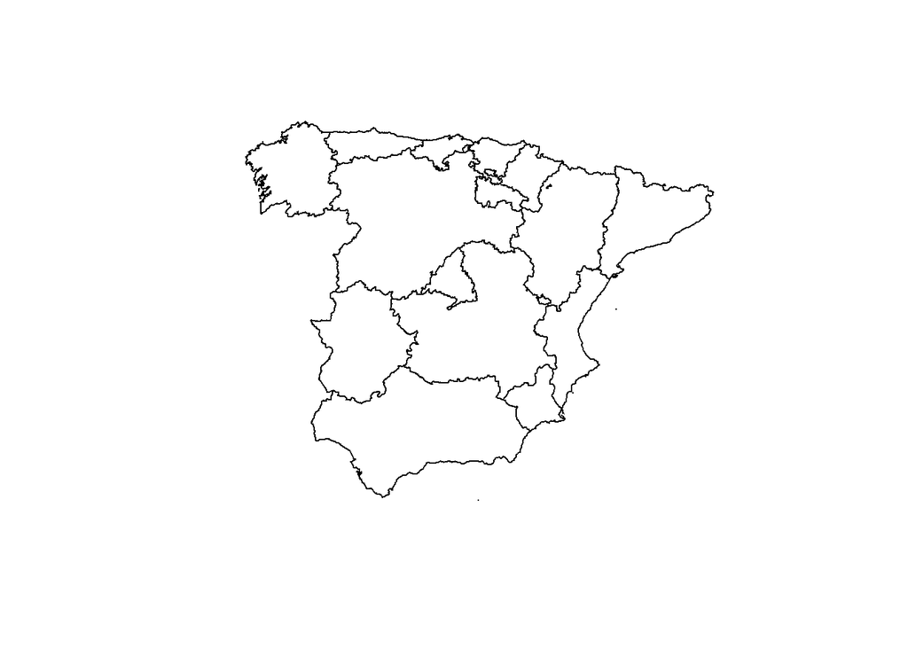

```r
#MAPA ESPAÑA POR COMUNIDADES AUTONOMAS

Spain<-mapSpain::esp_get_prov()

mapa_Spain<- Spain%>%
  filter(!codauto %in% c("04","05","18","19")) %>%
  group_by(codauto) %>%
  summarise()
crs <- st_crs("EPSG:4258")
plot(mapa_Spain$geometry)
```

### CARGA DE DATOS DE LA BASE DE DATOS RELACIONAL

Accedemos a la respectiva base de datos y lanzamos una query para leer nuestros datos. Una vez cargados los datos en nuestro environment comprobamos que la carga haya sido correcta pintandolos sobre el mapa de españa (creado en el apartado anterior).

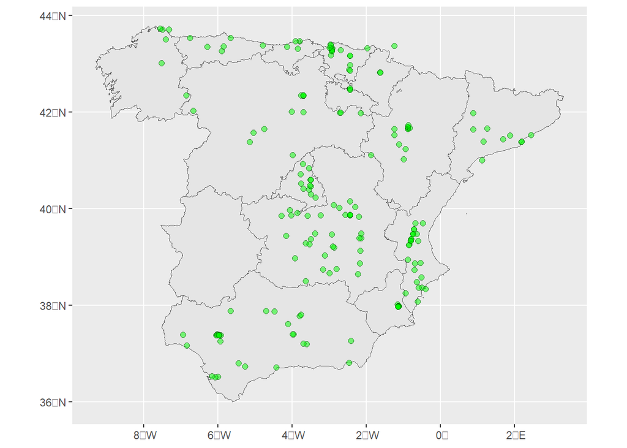

```r
con<- dbConnect(odbc::odbc(),
                dsn = "fuente",
                Database ="Proyecto_Espaciales")

query<- "SELECT * FROM VEHICULOS"

tabla<-dbGetQuery(con,query)

datos <- st_as_sf(tabla, coords = c("Longitud", "Latitud"), crs = crs) %>%
  st_transform(crs)

ggplot() +
  geom_sf(data = mapa_Spain)+
  geom_sf(data=datos$geometry, fill = "green", alpha = .5, size = 2, shape = 21)
```

## **Analisis exploratorio de datos**

Una vez cargados los datos de origen, realizamos las transformaciones necesarias corrigiendo los diferentes errores que estos presentaban.

```r
unique(datos$Com_Aut)
```

```
##  [1] "CV"        "Madrid"    "Galicia"   "CM"        "Catalunya" "CL"
##  [7] "PV"        "Andalucía" "Cantabria" "Asturias"  "Murcia"    "La Rioja"
## [13] "Navarra"   "Álava"     "Aragón"    "Avilés"    "Huelva"
```

```r
datos$Com_Aut <- ifelse(datos$Com_Aut == 'Álava', 'PV', datos$Com_Aut)

datos$Com_Aut <- ifelse(datos$Com_Aut == 'Avilés', 'Asturias', datos$Com_Aut)

datos$Com_Aut <- ifelse(datos$Com_Aut == 'Huelva', 'Andalucía', datos$Com_Aut)

unique(datos$Com_Aut)
```

```
##  [1] "CV"        "Madrid"    "Galicia"   "CM"        "Catalunya" "CL"
##  [7] "PV"        "Andalucía" "Cantabria" "Asturias"  "Murcia"    "La Rioja"
## [13] "Navarra"   "Aragón"
```

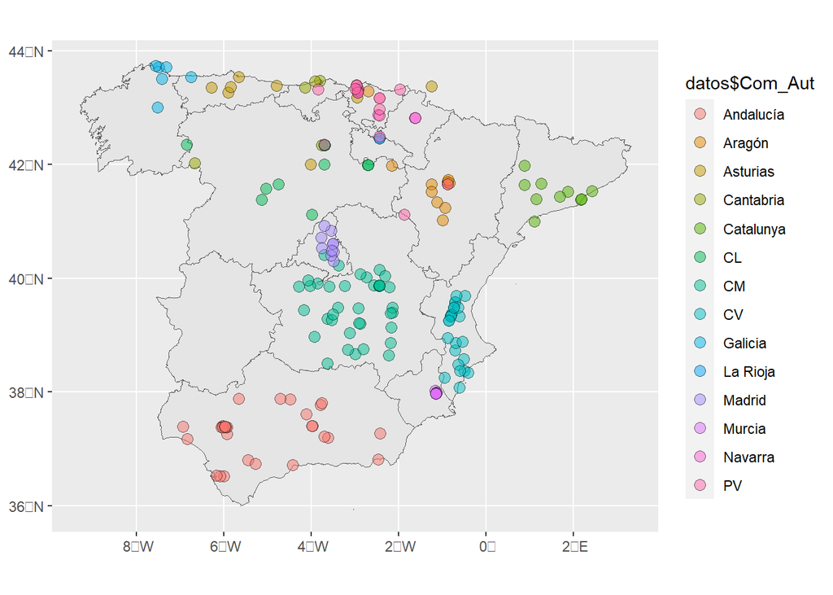

```r
ggplot() +
  geom_sf(data = mapa_Spain)+
  geom_sf(data=datos$geometry,  aes(fill = datos$Com_Aut), alpha = .5, size = 3, shape = 21)
```

```r
#Asignamos a cada dato su correspondiente comunidad autónoma

datos[154,]$Com_Aut<-"Asturias"
datos[57,]$Com_Aut<-"Madrid"
datos[56,]$Com_Aut<-"Madrid"
datos[151,]$Com_Aut<-"Cantabria"
datos[141,]$Com_Aut<-"CL"
datos[142,]$Com_Aut<-"Aragón"
datos[149,]$Com_Aut<-"Aragón"
datos[155,]$Com_Aut<-"CL"
datos[123,]$Com_Aut<-"CL"
datos[140,]$Com_Aut<-"CL"
datos[135,]$Com_Aut<-"PV"
datos[145,]$Com_Aut<-"PV"
datos[150,]$Com_Aut<-"PV"
datos[157,]$Com_Aut<-"La Rioja"

#Eliminamos dato cuya coordenada es erronea
datos<- datos[-148,]


COM<-c("CV", "Madrid" , "Galicia" ,"CM" ,"Catalunya", "CL", "PV"  ,  "Andalucía" ,
       "Cantabria" , "Asturias" , "Murcia" ,   "La Rioja" , "Navarra" ,  "Aragón"  )

for (com in COM) {
  datos_filtrados <- filter(datos, Com_Aut == com)
  assign(paste0(com), datos_filtrados)
}
```

### VISUALIZACIÓN DE LA CORRECIÓN DE LOS DATOS

```r
#Observamos cuantos vehículos hay en cada comunidad

for (nombre in COM) {
  n_filas <- nrow(get(nombre))
  cat("La Comunidad ", nombre, "tiene", n_filas, "vehiculos.\n")
}
```

```
## La Comunidad  CV tiene 28 vehiculos.
## La Comunidad  Madrid tiene 12 vehiculos.
## La Comunidad  Galicia tiene 5 vehiculos.
## La Comunidad  CM tiene 36 vehiculos.
## La Comunidad  Catalunya tiene 10 vehiculos.
## La Comunidad  CL tiene 14 vehiculos.
## La Comunidad  PV tiene 18 vehiculos.
## La Comunidad  Andalucía tiene 28 vehiculos.
## La Comunidad  Cantabria tiene 4 vehiculos.
## La Comunidad  Asturias tiene 6 vehiculos.
## La Comunidad  Murcia tiene 10 vehiculos.
## La Comunidad  La Rioja tiene 3 vehiculos.
## La Comunidad  Navarra tiene 2 vehiculos.
## La Comunidad  Aragón tiene 12 vehiculos.
```

```r
#Cramos una tabla con el número de vehículos por cada comunidad autónoma

table_Vehiculos <- data.frame(Comunidad = character(),
                    Cantidad = numeric(),
                    stringsAsFactors = FALSE)
for (nombre in COM) {
  n_filas <- nrow(get(nombre))
  nueva_fila <- data.frame(Comunidad = nombre,
                           Cantidad = n_filas)
  table_Vehiculos <- rbind(table_Vehiculos, nueva_fila)
}

table_Vehiculos
```

```
##    Comunidad Cantidad
## 1         CV       28
## 2     Madrid       12
## 3    Galicia        5
## 4         CM       36
## 5  Catalunya       10
## 6         CL       14
## 7         PV       18
## 8  Andalucía       28
## 9  Cantabria        4
## 10  Asturias        6
## 11    Murcia       10
## 12  La Rioja        3
## 13   Navarra        2
## 14    Aragón       12
```

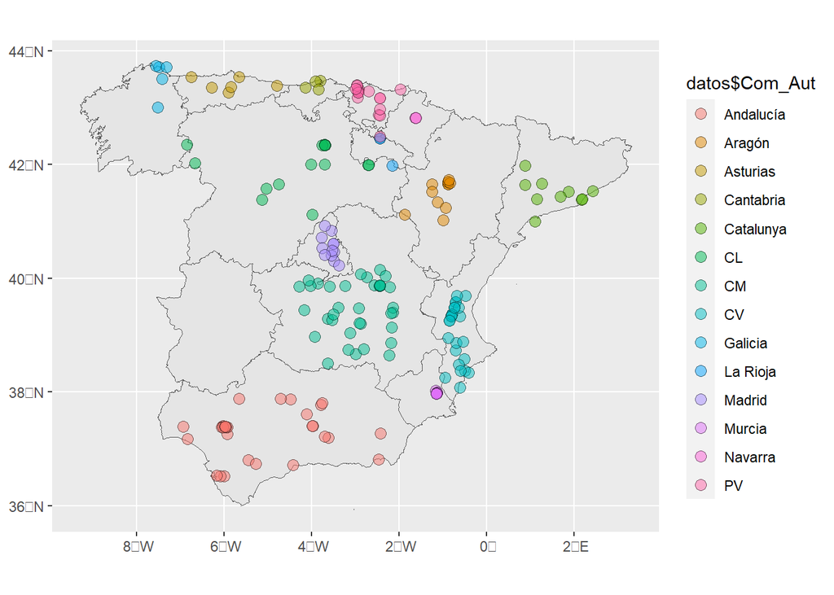

```r
#Pintamos los vehículos sobre el mapa
ggplot() +
  geom_sf(data = mapa_Spain)+
  geom_sf(data=datos$geometry,  aes(fill = datos$Com_Aut), alpha = 0.5, size = 3, shape = 21)
```

## **Comunidades autónomas**

### CREACIÓN CUADRANTE PARA LAS COMUNIDADES AUTÓNOMAS

Primero, creamos los diferentes centros lógisticos con los que cuenta nuestra compañia. Acto seguido, construimos nuesto correspondiente bounding box y superponemos la cuadricula 3x3 (GRID) al mapa de la Peninsula Ibérica.

#### Creación centros logísticos

```r
 df <- data.frame(
   Ubicacion = c("Córdoba", "Almazora", "Alcalá de Henares", "Zuera", "Gijón"),
   Longitud = c(-4.779836, -0.152802, -3.364611, -0.762481, -5.661522),
   Latitud = c(37.888175, 39.957313, 40.481663, 41.868992, 43.532201) )

 Centros_logisticos <- st_as_sf(df, coords = c("Longitud", "Latitud"), crs = crs) %>%
   st_transform(crs)

 cent<- data.frame(x = df$Longitud, y = df$Latitud) %>%
   st_as_sf(coords = c("x", "y"))

 w2 <- st_bbox(c(xmin = -8, ymin = 35, xmax = 2.6, ymax = 44)) %>%
   st_as_sfc()

 as.ppp(cent)
```

```
## Planar point pattern: 5 points
## window: rectangle = [-5.661522, -0.152802] x [37.88817, 43.5322] units
```

```r
 pp2 <- as.ppp(c(w2, st_geometry(cent)))
 par(mfrow = c(1, 1), mar = rep(0, 4))

 #crear el cuadrante
 q2 = quadratcount(pp2, nx=3, ny=3)
```

#### Creación del cuadrante (GRID)

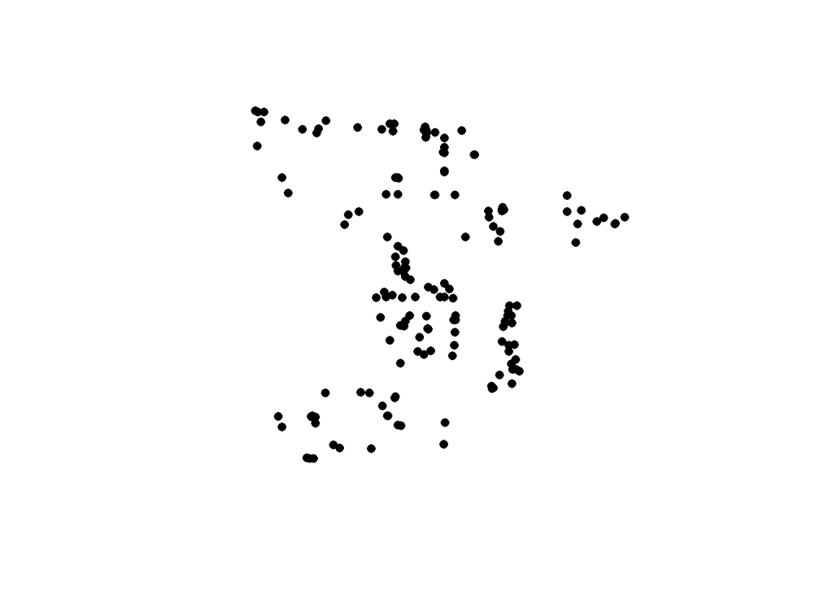

```r
plot(datos$geometry, pch=16)
```

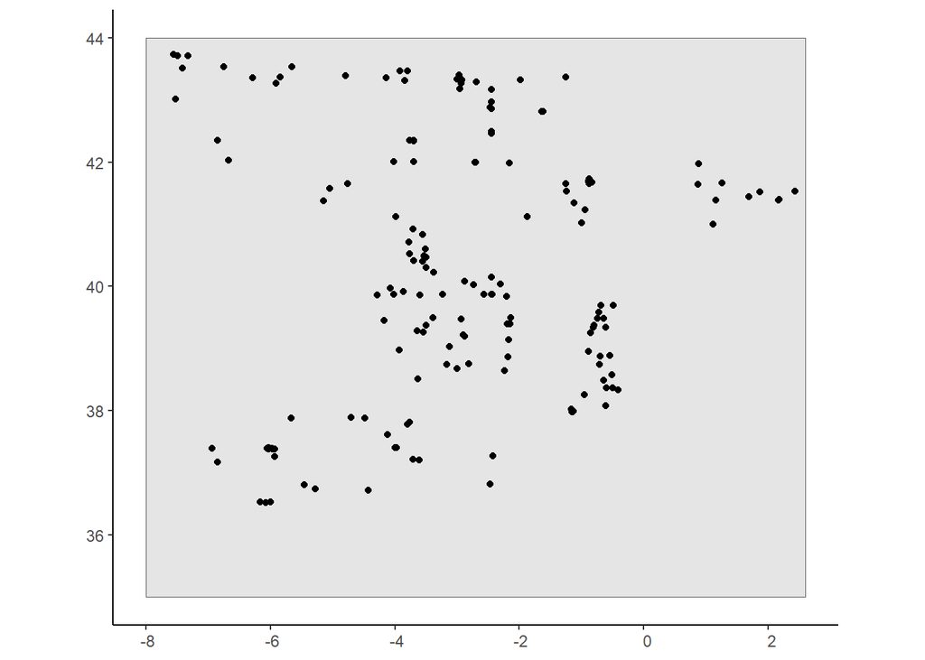

```r
xy <- data.frame(x = tabla$Longitud, y = tabla$Latitud) %>%
  st_as_sf(coords = c("x", "y"))


w1 <- st_bbox(c(xmin = -8, ymin = 35, xmax = 2.6, ymax = 44)) %>%
  st_as_sfc()

ggplot() +
  geom_sf(data = w1) + #coordenadas
  geom_sf(data = xy) +  #rellena con puntos
  theme_classic()
```

```r
as.ppp(xy)
```

```
## Planar point pattern: 189 points
## window: rectangle = [-7.562, 2.431886] x [36.51899, 43.729] units
```

```r
pp1 <- as.ppp(xy)
class(pp1)
```

```
## [1] "ppp"
```

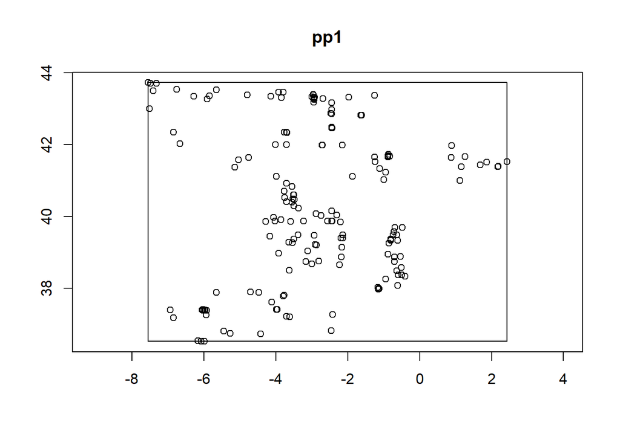

```r
plot(pp1, axes = T)
```

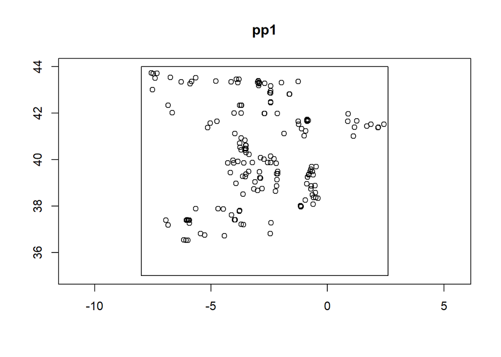

```r
#xy es un objeto sf y dentro de este es un point

pp1 <- as.ppp(c(w1, st_geometry(xy)))
plot(pp1, axes = T)
```

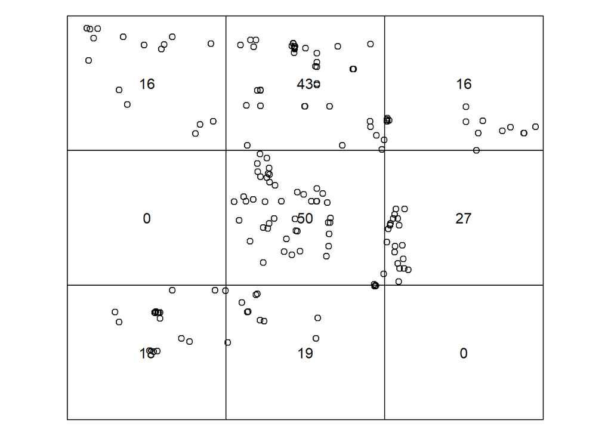

```r
par(mfrow = c(1, 1), mar = rep(0, 4))

#crear el cuadrante
q1 = quadratcount(pp1, nx=3, ny=3)
plot(q1, main = "")
plot(xy, add = TRUE)
```

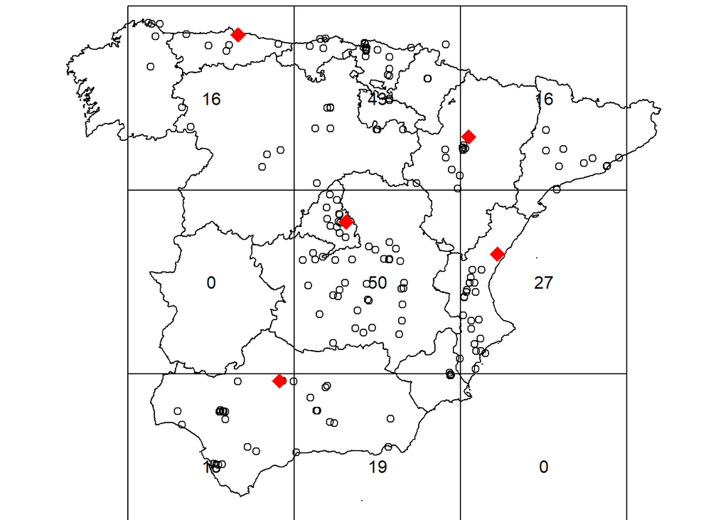

```r
#SUPERPONER A ESPAÑA
plot(mapa_Spain$geometry)
plot(q1, add = TRUE)
plot(pp1, add = TRUE)
plot(pp2, add = TRUE,col="red",pch = 18,
     cex = 2,
     bg = 0,
     lwd = 1,
     lty = 1)
```

## **Aleatoriedad**

#### Método Quadrant-test

Realizamos el método del Quadrant-test donde la hipotesis nula es que nuestros datos siguen una distribución completamente aleatoria. Debido el p-value obtenido, esta hipotesis es rechazada.

```r
#compara frecuencias esperadas con sus fercuencias observadas
quadrat.test(pp1, nx=3, ny=3)
```

```
##
##  Chi-squared test of CSR using quadrat counts
##
## data:  pp1
## X2 = 109.81, df = 8, p-value < 2.2e-16
## alternative hypothesis: two.sided
##
## Quadrats: 9 tiles (irregular windows)
```

#### Método basado en distancias

Realizamos el método basado en distancias mediante la famosa función G y gráficamos los resultados.

```r
#GRAFICA: #Pag 15

r <- seq(0, 0.25, len = 50)

ap <- envelope(pp1, fun=Gest, r=r, nrank=4, nsim=200)
```

[output not shown]

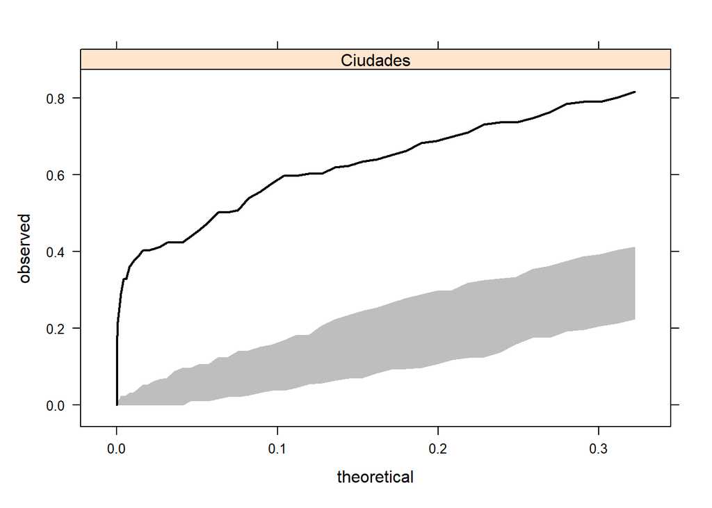

```r
y = rep("Ciudades", each=length(r))
ap <- cbind(ap, y)

print(xyplot(obs~theo|y, data=ap, type="l",
             xlab = "theoretical", ylab = "observed",
             panel=function(x, y, subscripts){
               lpolygon(c(x, rev(x)),
                        c(ap$lo[subscripts], rev(ap$hi[subscripts])),
                        border="gray", col = "gray")
               llines(x, y, col="black", lwd=2)}
))
```

### DENSIDAD POR COMUNIDADES AUTÓNOMAS

Para poder realizar el analisis de la densidad, tenemos que pasar nuestros datos a coordenadas planas. Una vez realizada esta transformación y creada la ventana, utilizamos la función density para estimar la densidad.

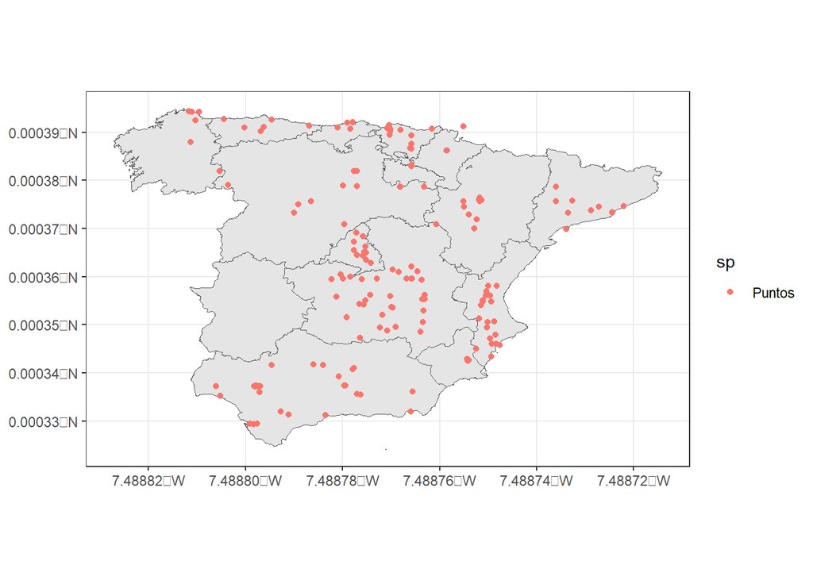

```r
#PASAMOS LOS DATOS A COORDENADAS PLANAS:

rm(datos)
rm(crs)

crs = 32630
datos <- st_as_sf(tabla, coords = c("Longitud", "Latitud"), crs = crs) %>%
  st_transform(crs)

 Spain<-mapSpain::esp_get_prov()
 mapa_Spain<- Spain%>%
 filter(!codauto %in% c("04","05","18","19")) %>% group_by(codauto) %>% summarise()


 mapa.sf <- st_as_sf(mapa_Spain, coords = geometry)
 st_crs(mapa.sf) <- crs

datos <- st_as_sf(tabla, coords = c("Longitud", "Latitud"), crs = crs) %>%  st_transform(crs)
 spain_only2 <- st_transform(mapa.sf)

 xy <- data.frame(x = tabla$Longitud, y = tabla$Latitud) %>% st_as_sf(coords = c("x", "y"))
 st_crs(xy)<- 32630

 pts.sf2 <- xy %>% st_sf() %>% mutate(sp="Puntos")
 st_crs(pts.sf2)<- 32630


 p1 <- ggplot() +
    geom_sf(data=spain_only2) +
     geom_sf(data=pts.sf2,aes(shape=sp,color=sp)) +
      theme_bw() +
      coord_sf()

 p1
```

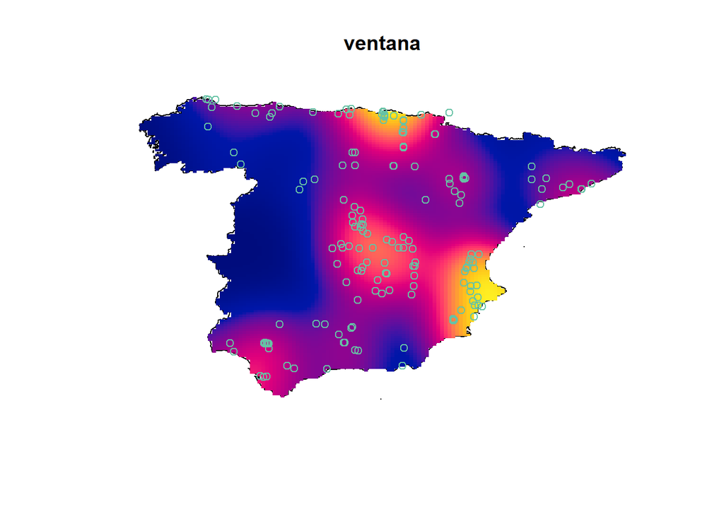

```r
 ventana <- spatstat.geom::as.owin(st_geometry(spain_only2))
  pts <- as.ppp(
      X = st_coordinates(pts.sf2),
      W = ventana
    )

#den1 <- density(pts, sigma = bw.diggle)
den1 <- density(pts, sigma = 0.7)
 par(mfrow = c(1,1))
 plot(ventana)
 plot(den1,add= TRUE)
 plot(pts.sf2, add = TRUE)
```

## **Tipo de vehículo**

### ANALISIS DE LOS DATOS POR TIPO DE VEHICULO

```r
 rm(datos)
 rm(crs)
 crs <- st_crs("EPSG:4258")
 datos <- st_as_sf(tabla, coords = c("Longitud", "Latitud"), crs = crs) %>%
   st_transform(crs)


#Creamos una tabla para cada tipo de vehículo:

 vehiculos <- c("Tractor", "Elevadora", "Furgoneta", "Grua", "Retráctil", "Transpaleta")
 for (vehiculo in vehiculos) {
   datos_filtrados <- filter(datos, Tipo_Vehiculo == vehiculo)
   assign(paste0(vehiculo), datos_filtrados)
 }

#Vemos cuantos vehículos de cada tipo hay:

 for (nombre in vehiculos) {
   n_filas <- nrow(get(nombre))
   cat("El data frame", nombre, "tiene", n_filas, "filas.\n")
 }
```

```
## El data frame Tractor tiene 42 filas.
## El data frame Elevadora tiene 40 filas.
## El data frame Furgoneta tiene 37 filas.
## El data frame Grua tiene 38 filas.
## El data frame Retráctil tiene 14 filas.
## El data frame Transpaleta tiene 18 filas.
```

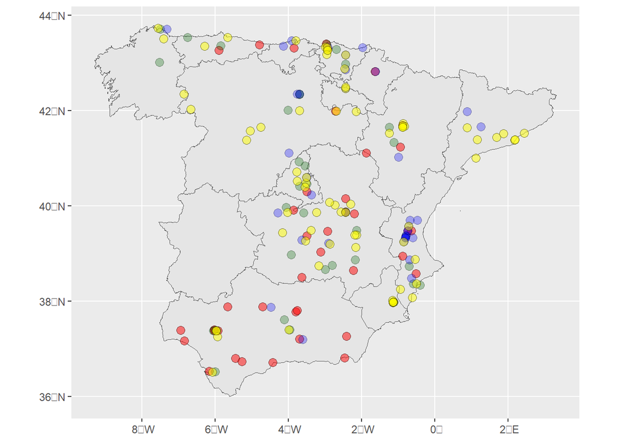

```r
 #Eliminamos de nuevo el dato cuyas coordenadas eran erroneas
 Furgoneta<-Furgoneta[-29,]

 #Color amarillo los de maquinjaria almacen (retractil, transpaleta, Elevadora),
 #colores fuerte vehiculos pesados (Tractor furgoneta Grua)

 ggplot() +
   geom_sf(data = mapa_Spain)+
   geom_sf(data=Tractor$geometry, fill = "red", alpha = .5, size = 3, shape = 21)+
   geom_sf(data=Furgoneta$geometry, fill = "darkgreen", alpha = .3, size = 3, shape = 21)+
   geom_sf(data=Grua$geometry, fill = "blue", alpha = .3, size = 3, shape = 21)+
   geom_sf(data=Retráctil$geometry, fill = "yellow", alpha = .5, size = 3, shape = 21)+
   geom_sf(data=Transpaleta$geometry, fill = "yellow", alpha = .5, size = 3, shape = 21)+
   geom_sf(data=Elevadora$geometry, fill = "yellow", alpha = .5, size = 3, shape = 21)
```

### CREACIÓN CUADRANTES SEGÚN TIPO DE VEHICULO (GRID)

Creamos de nuevo las correspondientes cuadriculas para cada tipo de vehículo.

```r
 rm(xy)
 xy <- st_as_sf(tabla, coords = c("Longitud", "Latitud"))

 vehiculos <- c("Tractor", "Elevadora", "Furgoneta", "Grua", "Retráctil", "Transpaleta")
 for (vehiculo in vehiculos) {
   datos_filtrados <- filter(xy, Tipo_Vehiculo == vehiculo)
   assign(paste0(vehiculo), datos_filtrados)
 }

 w1 <- st_bbox(c(xmin = -8, ymin = 35, xmax = 2.6, ymax = 44)) %>%
   st_as_sfc()
```

#### Creación del cuadrante (GRID) para los tractores

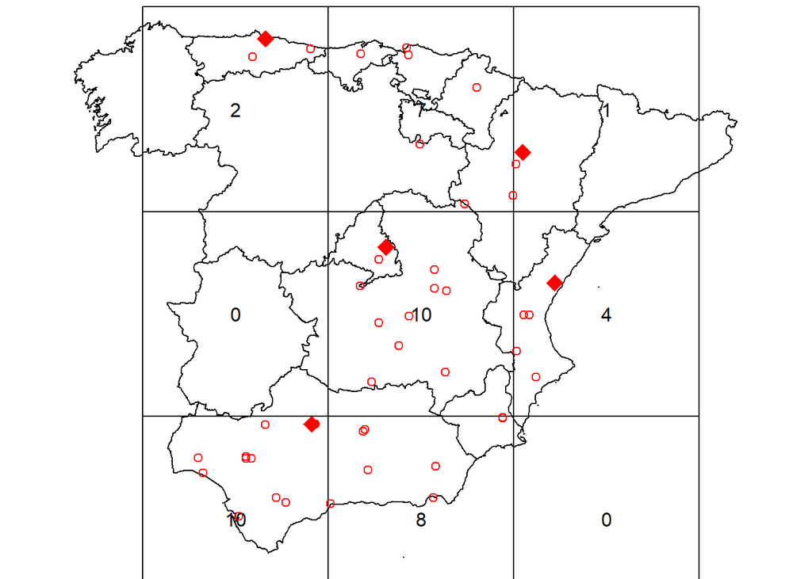

```r
  pp1 <- as.ppp(c(w1, st_geometry(Tractor$geometry)))
 par(mfrow = c(1, 1), mar = rep(0, 4))

 #crear el cuadrante
 q1<- quadratcount(pp1, nx=3, ny=3)

 #SUPERPONER A ESPAÑA
 plot(mapa_Spain$geometry)
 plot(q1 ,add = TRUE)
 plot(pp1, add = TRUE, col="red")
 plot(pp2, add = TRUE,col="red",pch = 18,
      cex = 2,
      bg = 0,
      lwd = 1,
      lty = 1)
```

#### Creación del cuadrante (GRID) para las gruas

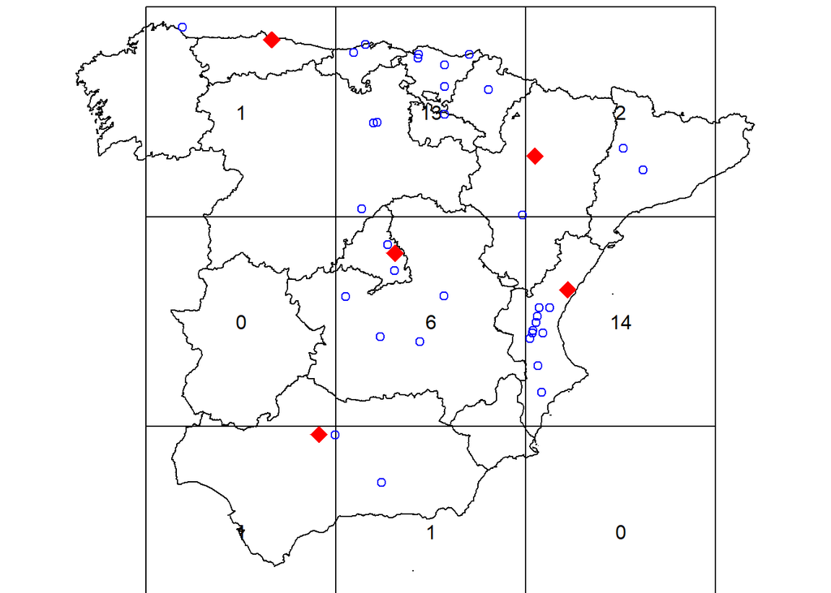

```r
 #GRUA

 pp1 <- as.ppp(c(w1, st_geometry(Grua$geometry)))
 par(mfrow = c(1, 1), mar = rep(0, 4))

 #crear el cuadrante
 q1<- quadratcount(pp1, nx=3, ny=3)

 #SUPERPONER A ESPAÑA
 plot(mapa_Spain$geometry)
 plot(q1 ,add = TRUE)
 plot(pp1, add = TRUE, col="Blue")
 plot(pp2, add = TRUE,col="red",pch = 18,
      cex = 2,
      bg = 0,
      lwd = 1,
      lty = 1)
```

#### Creación del cuadrante (GRID) para las furgonetas

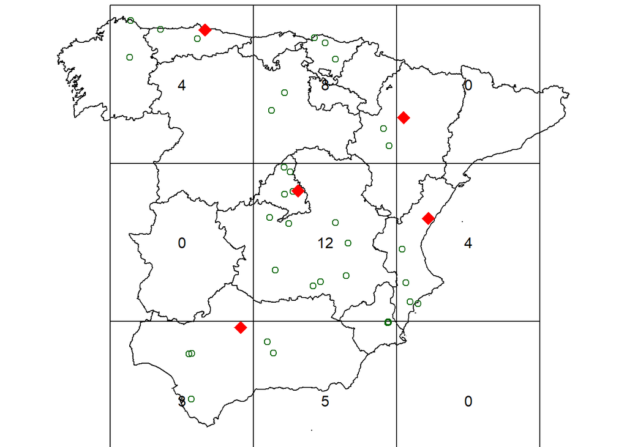

```r
 #FURGONETA

 Furgoneta<-Furgoneta[-29,]

 pp1 <- as.ppp(c(w1, st_geometry(Furgoneta$geometry)))
 par(mfrow = c(1, 1), mar = rep(0, 4))

 #crear el cuadrante
 q1<- quadratcount(pp1, nx=3, ny=3)

 #SUPERPONER A ESPAÑA
 plot(mapa_Spain$geometry)
 plot(q1 ,add = TRUE)
 plot(pp1, add = TRUE, col="darkgreen")
 plot(pp2, add = TRUE,col="red",pch = 18,
      cex = 2,
      bg = 0,
      lwd = 1,
      lty = 1)
```

#### Creación del cuadrante (GRID) para la maquinaria de almacén

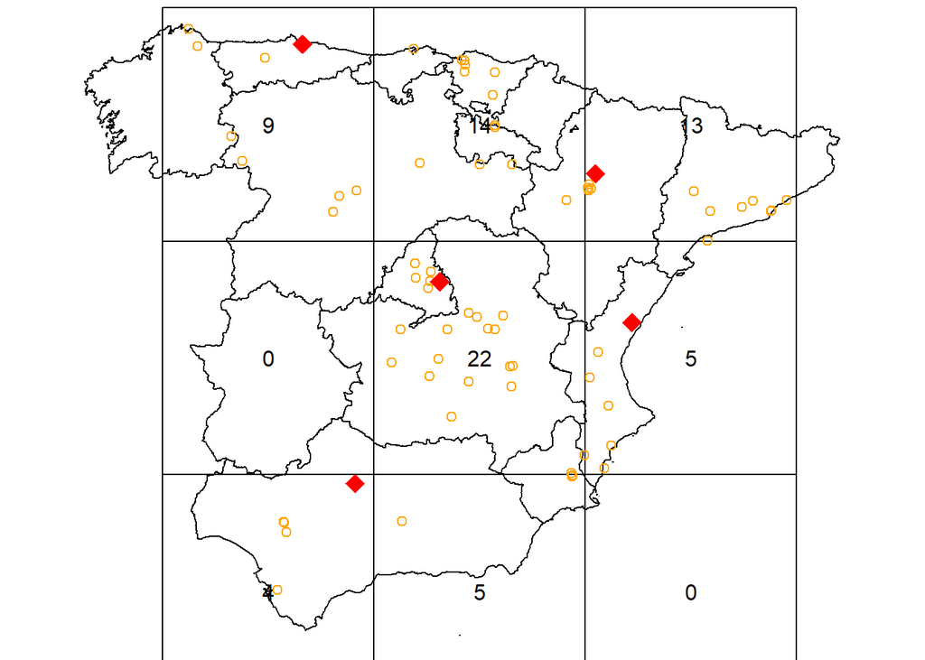

```r
 #MAQUINARIA

Maquinaria<- filter(xy, Tipo_Vehiculo == "Transpaleta" | Tipo_Vehiculo == "Elevadora" | Tipo_Vehiculo =="Retráctil")

 w1 <- st_bbox(c(xmin = -8, ymin = 35, xmax = 2.6, ymax = 44)) %>%
   st_as_sfc()
 pp1 <- as.ppp(c(w1, st_geometry(Maquinaria$geometry)))
 par(mfrow = c(1, 1), mar = rep(0, 4))

 #crear el cuadrante
 q1<- quadratcount(pp1, nx=3, ny=3)

 #SUPERPONER A ESPAÑA

 plot(mapa_Spain$geometry)
 plot(q1 ,add = TRUE)
 plot(pp1, add = TRUE, col="orange")
 plot(pp2, add = TRUE,col="red",pch = 18,
      cex = 2,
      bg = 0,
      lwd = 1,
      lty = 1)
```

### DENSIDAD POR TIPO DE VEHICULO

Estimamos la densidad para cada tipo de vehículo.

```r
 rm(datos)
 rm(crs)
 crs = 32630
 datos <- st_as_sf(tabla, coords = c("Longitud", "Latitud"), crs = crs) %>%
   st_transform(crs)
```

#### Densidad para los tractores

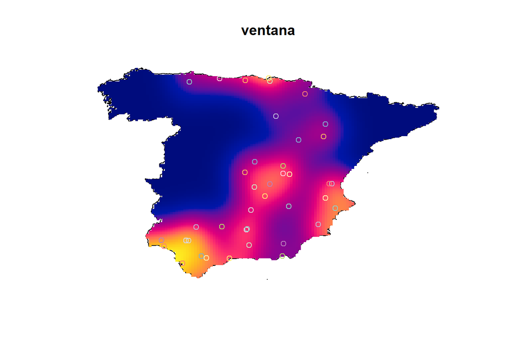

```r
 #PARA Tractor

 xy <- Tractor
 st_crs(xy)<- 32630
 pts.sf2 <- xy %>% st_sf() %>% mutate(sp="Puntos")
 st_crs(pts.sf2)<- 32630

 ventana <- spatstat.geom::as.owin(st_geometry(spain_only2))
 pts <- as.ppp(
   X = st_coordinates(pts.sf2),
   W = ventana
 )

 den1 <- density(pts, sigma = bw.diggle)
 den1 <- density(pts, sigma = 0.6)
 par(mfrow = c(1,1))
 plot(ventana)
 plot(den1,add= TRUE)
 plot(pts.sf2, add = TRUE)
```

#### Densidad para las gruas

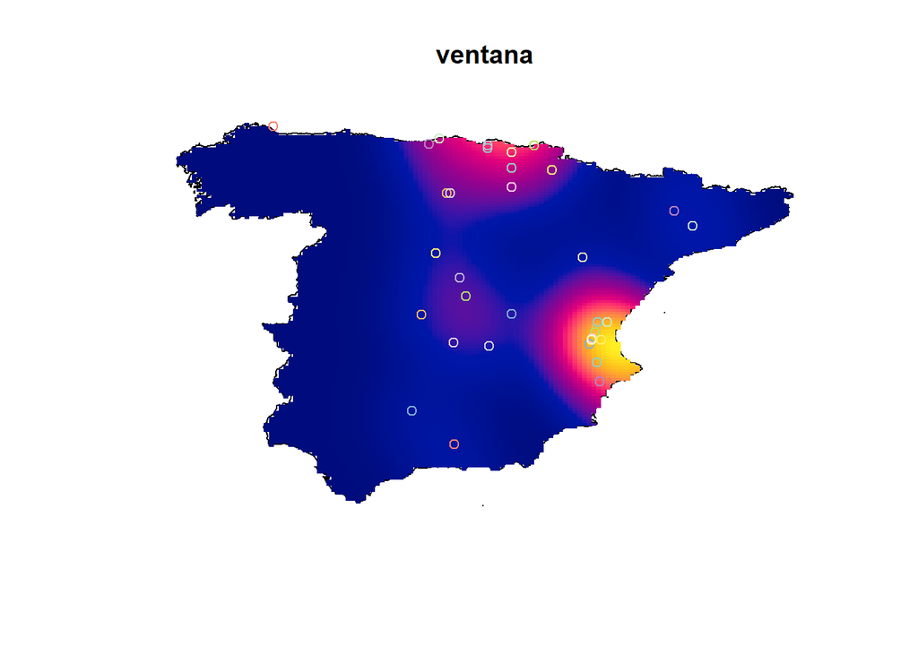

```r
 #PARA GRUAS:

 xy <- Grua
 st_crs(xy)<- 32630
 pts.sf2 <- xy %>% st_sf() %>% mutate(sp="Puntos")
 st_crs(pts.sf2)<- 32630

 ventana <- spatstat.geom::as.owin(st_geometry(spain_only2))
 pts <- as.ppp(
   X = st_coordinates(pts.sf2),
   W = ventana
 )

 den1 <- density(pts, sigma = bw.diggle)
 den1 <- density(pts, sigma = 0.7)
 par(mfrow = c(1,1))
 plot(ventana)
 plot(den1,add= TRUE)
 plot(pts.sf2, add = TRUE)
```

#### Densidad para las furgonetas

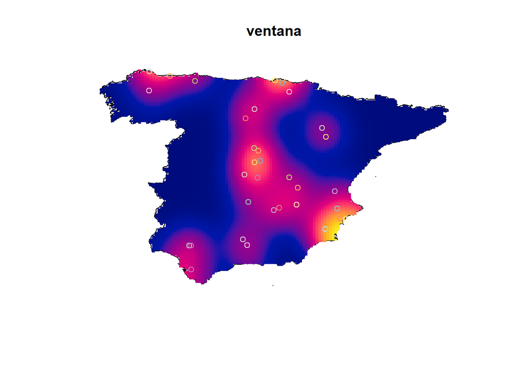

```r
 #PARA Furgoneta

 xy <- Furgoneta
 st_crs(xy)<- 32630
 pts.sf2 <- xy %>% st_sf() %>% mutate(sp="Puntos")
 st_crs(pts.sf2)<- 32630

 ventana <- spatstat.geom::as.owin(st_geometry(spain_only2))
 pts <- as.ppp(
   X = st_coordinates(pts.sf2),
   W = ventana
 )

 den1 <- density(pts, sigma = bw.diggle)
 den1 <- density(pts, sigma = 0.6)
 par(mfrow = c(1,1))
 plot(ventana)
 plot(den1,add= TRUE)
 plot(pts.sf2, add = TRUE)
```

#### Densidad para la maquinaria de almacén

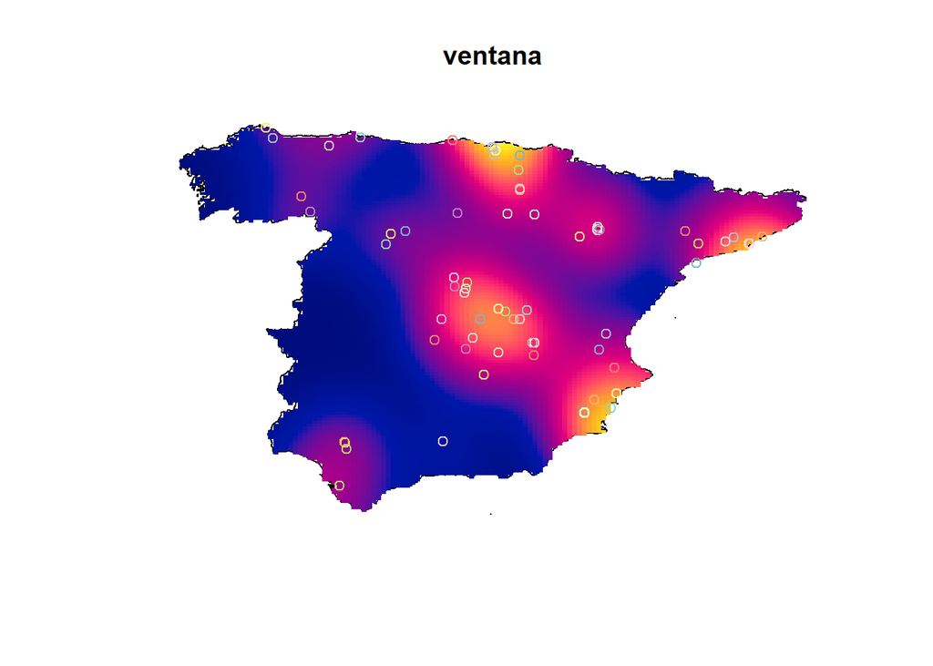

```r
 #PARA MAQUINARIA

 xy <- Maquinaria
 st_crs(xy)<- 32630
 pts.sf2 <- xy %>% st_sf() %>% mutate(sp="Puntos")
 st_crs(pts.sf2)<- 32630

 ventana <- spatstat.geom::as.owin(st_geometry(spain_only2))
 pts <- as.ppp(
   X = st_coordinates(pts.sf2),
   W = ventana
 )

 den1 <- density(pts, sigma = bw.diggle)
 den1 <- density(pts, sigma = 0.7)
 par(mfrow = c(1,1))
 plot(ventana)
 plot(den1,add= TRUE)
 plot(pts.sf2, add = TRUE)
```